# Chap_2_ggplot

### Scales

To specify the scales of a continuous variable :

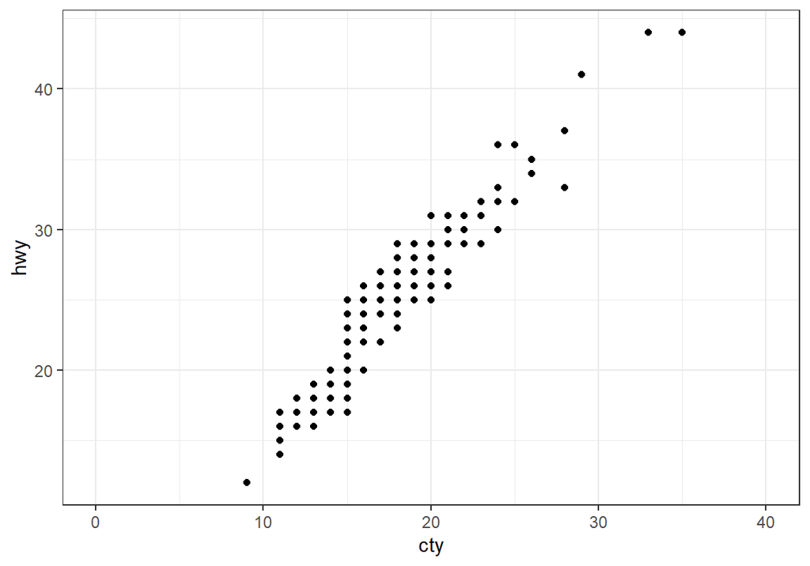

```r
ggplot(mpg) + aes(cty, hwy) + geom_point() +
  scale_x_continuous(limits = c(0,40))
```

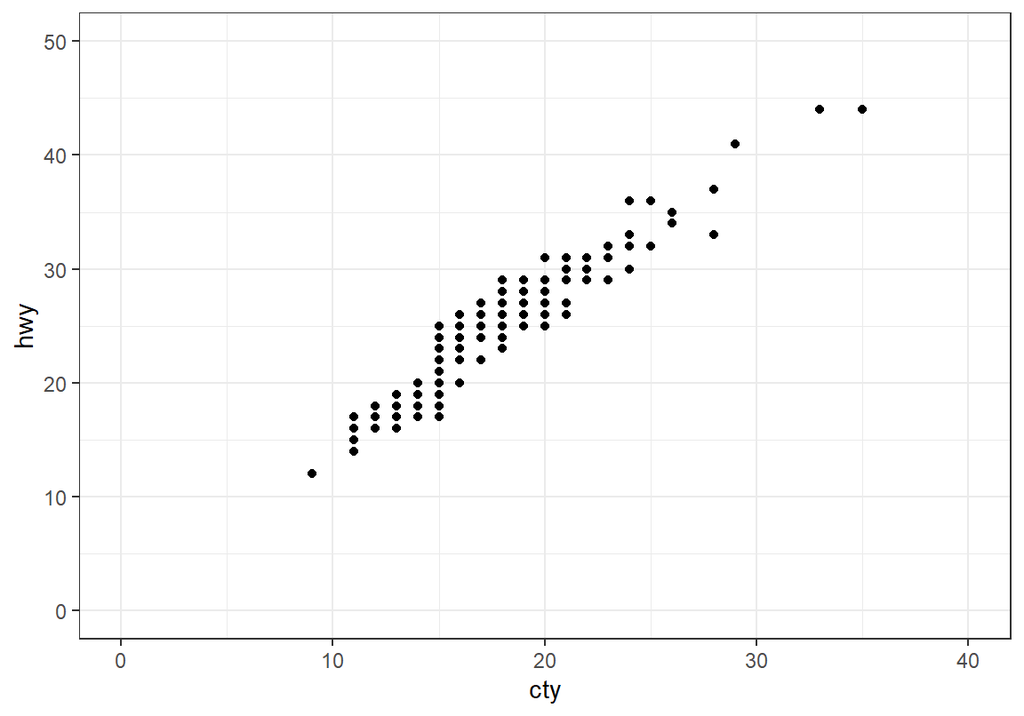

```r
# Or

ggplot(mpg) + aes(cty, hwy) + geom_point() +
  lims(x = c(0,40), y = c(0,50))
```

To zoom in a particular zone, use coord_cartesian instead of ylim (because this one truncate the data outside of the limits)

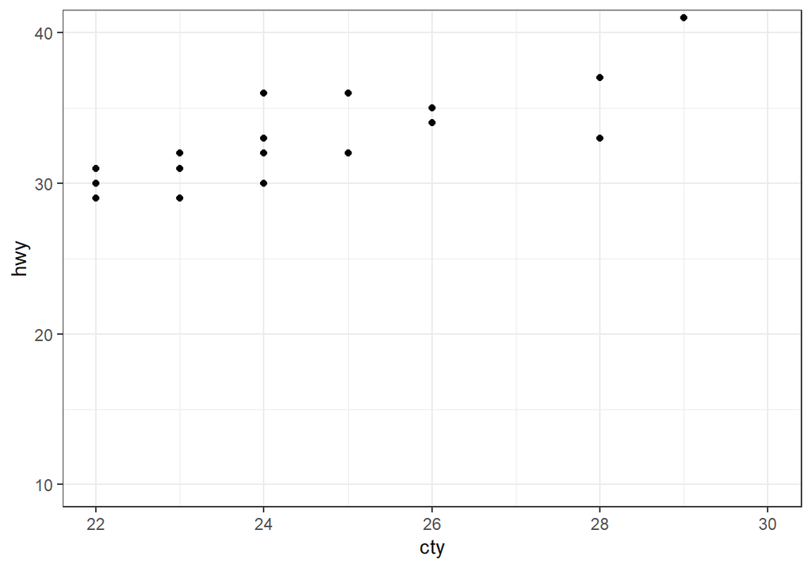

```r
ggplot(mpg) + aes(cty, hwy) + geom_point() +
  coord_cartesian(xlim = c(22,30), ylim = c(10,40))
```

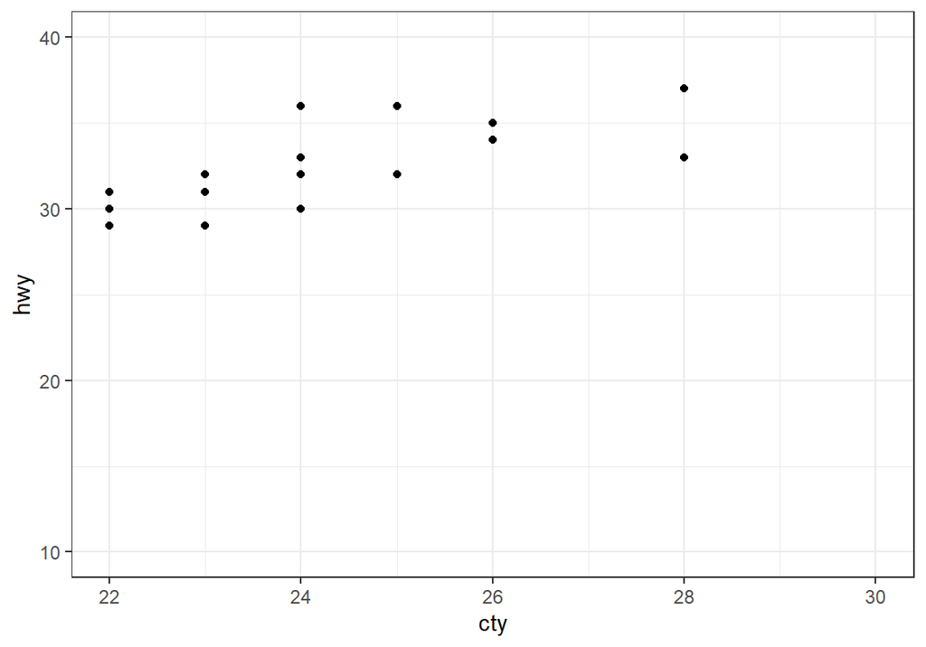

```r
ggplot(mpg) + aes(cty, hwy) + geom_point() +
  xlim(22,30) + ylim(10,40)
```

To change the ticks marks of a scale, use the `break` option with a vector

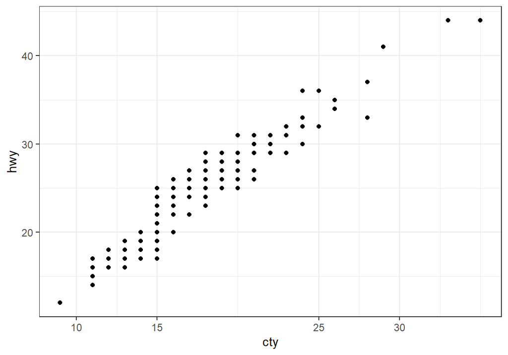

```r
ggplot(mpg) + aes(cty, hwy) + geom_point() +
  scale_x_continuous(breaks = c(0,10,15,25,30))
```

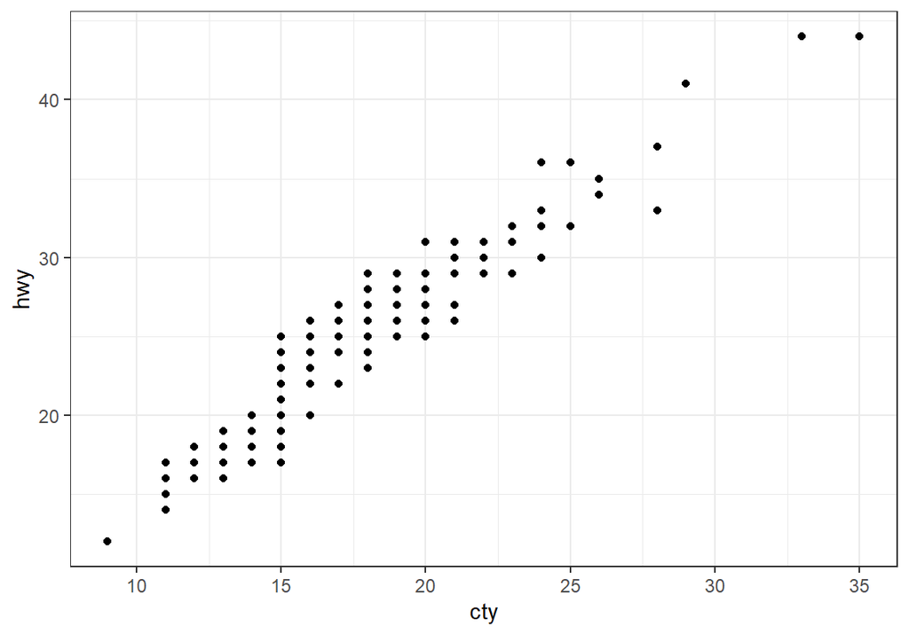

```r
# Use the function breaks_pretty from the scales package to use suitable breaks

ggplot(mpg) + aes(cty, hwy) + geom_point() +
  scale_x_continuous(breaks = scales::breaks_pretty())
```

To add labels at the breaks, use the `labels` option

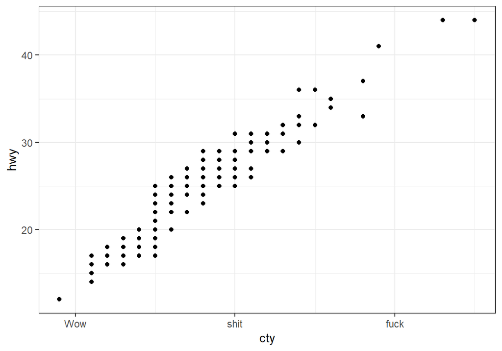

```r
ggplot(mpg) + aes(cty, hwy) + geom_point() +
  scale_x_continuous(breaks = c(10,20,30), labels = c("Wow", "shit", "fuck"))
```

To use transformations of the data, use the `trans` option

To categorize a continuous variable into bins, use `scale_x_binned`

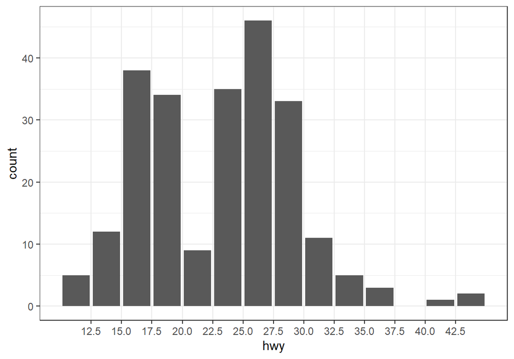

```r
ggplot(mpg) + aes(hwy) + geom_bar() +
  scale_x_binned(n.breaks = 12)
```

To change the value on a continuous scale, use `limits` option in the `scale_color_continuous`

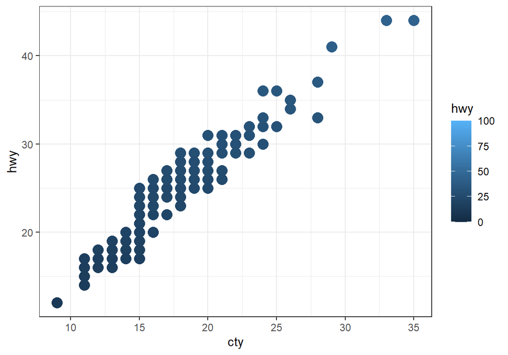

```r
ggplot(mpg) + aes(cty, hwy, col = hwy) + geom_point(size = 4) +
  scale_color_continuous(limits = c(0,100))
```

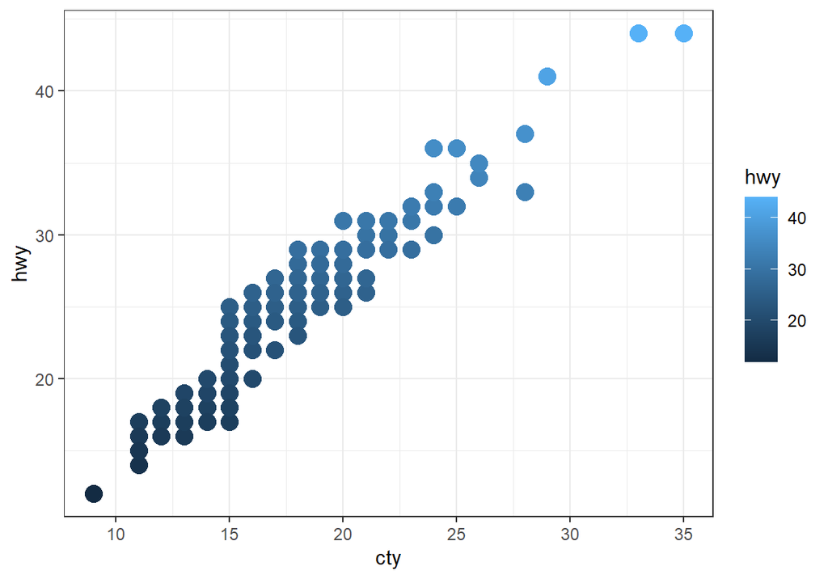

```r
ggplot(mpg) + aes(cty, hwy, col = hwy) + geom_point(size = 4)
```

Idem for fill and other aesthetics

### Colour

To change the color of the points manually, use the `scale_<xxx>_manual` function

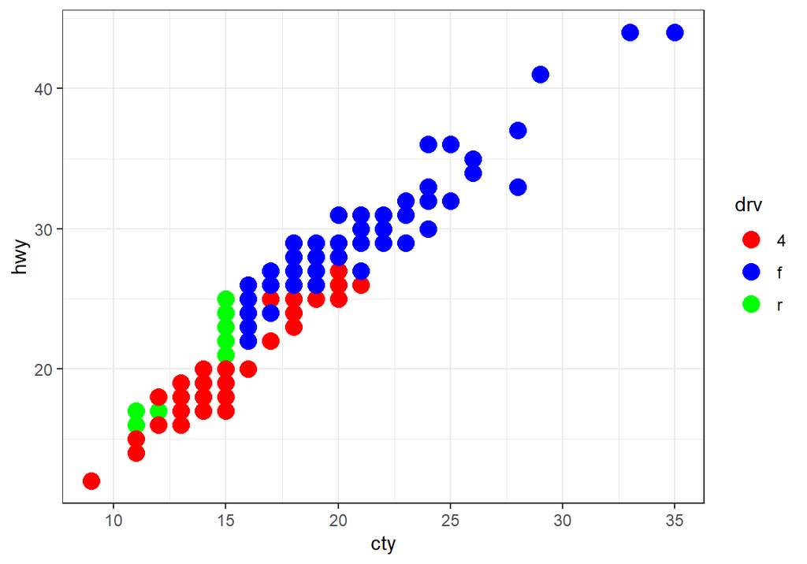

```r
ggplot(mpg) + aes(cty, hwy, col = drv) + geom_point(size = 4) +
  scale_color_manual(values = c("4" = "red","f" = "blue","r" = "green"))
```

### Shape

To make hollow shapes, use `scale_shape` and option `solid`

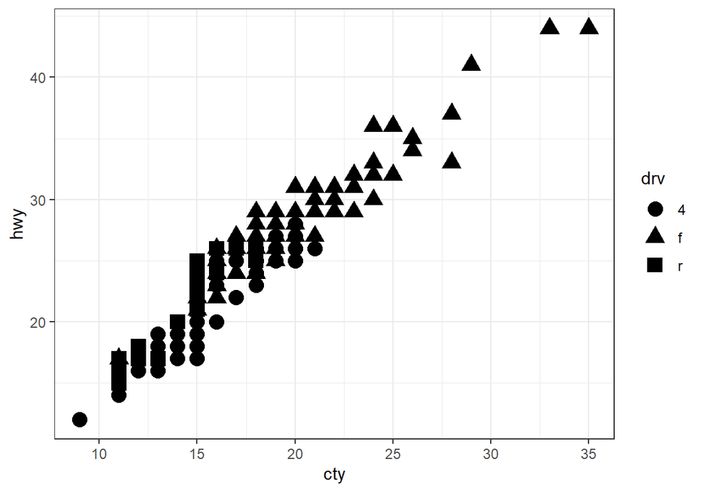

```r
ggplot(mpg) + aes(cty, hwy, shape = drv) + geom_point(size = 4) +
  scale_shape(solid = T)
```

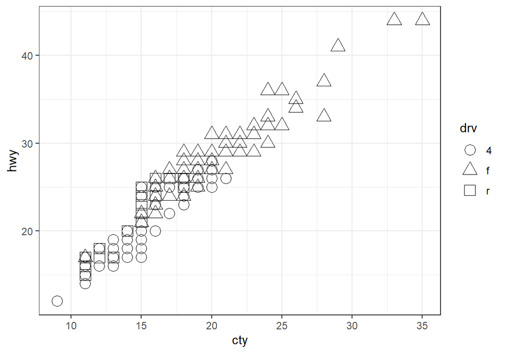

```r
ggplot(mpg) + aes(cty, hwy, shape = drv) + geom_point(size = 4) +
  scale_shape(solid = F)
```

Or use `scale_shape_manual` to set it for each value

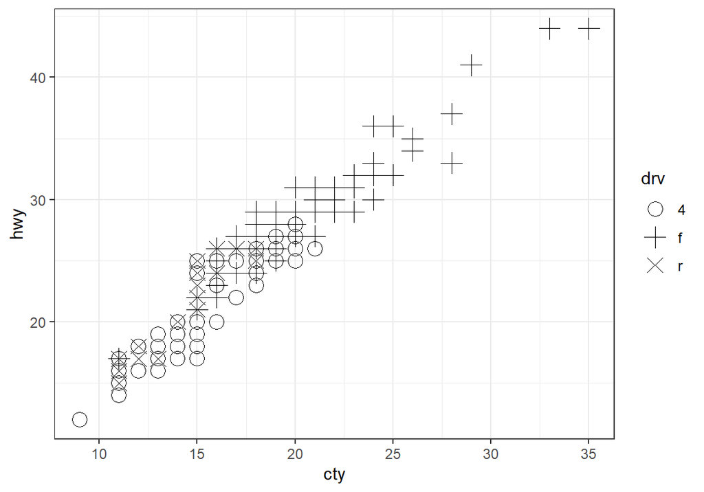

```r
ggplot(mpg) + aes(cty, hwy, shape = drv) + geom_point(size = 4) +
  scale_shape_manual(values = c(1,3,4))
```